# Chapter-8

[Bruce Hartman](https://drbrucehartman.net/brucewebsite/)

Last updated: 29 January, 2025

# Introduction

Chapter 8 discussion from the HEADS text.

# Packages

Regular R packages:

```r
library(tidyverse)
library(ggfortify)
library(GGally)
library(broom)
library(skimr)
library(gt)
library(patchwork)
library(yardstick)
library(car)
```

Github packages:

```r
library(devtools)
install_github("bhartman2/mbadtools")
```

```
Using GitHub PAT from the git credential store.
Skipping install of 'mbadtools' from a github remote, the SHA1 (22fd6b1c) has not changed since last install.
  Use `force = TRUE` to force installation
```

```r
library(mbadtools)
```

To install this package: use uncommented in your notebook.

```r
# install_github("bhartman2/HEADS")
# library(HEADS)
```

# Chapter 8

We work through some of the text examples from the book.

# Trees (8.1)

## Example 8.1.2

Data come from Table 8.1 of the HEADS text

```r
data(Table_8_1)
Table_8_1 %>% glimpse
```

```
Rows: 30
Columns: 3
$ GlucoseLevel <int> 110, 119, 79, 122, 158, 109, 158, 117, 71, …
$ BMI          <dbl> 27.8, 29.0, 43.5, 23.0, 29.8, 36.0, 31.6, 3…
$ Diabetes     <chr> "negative", "positive", "negative", "negati…
```

### Trees

Tree: we try an hclust tree, since it is easy.

```r
h = hclust(dist(Table_8_1))
ch = cutree(h,k=4 )
ch
```

```
 [1] 1 1 2 1 3 1 3 1 2 2 4 1 4 3 1 2 3 1 2 3 3 1 4 2 2 4 3 3 1 4
```

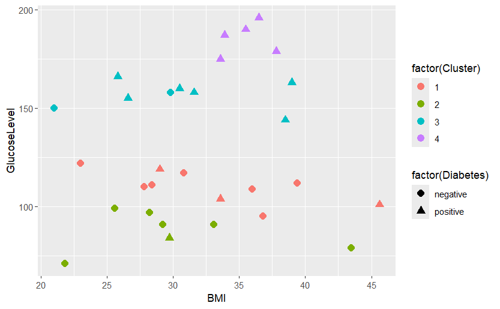

```r
dfh = data.frame(Table_8_1, Cluster=ch)
ggplot(dfh, aes(BMI, GlucoseLevel))+
  geom_point(aes(color=factor(Cluster), shape=factor(Diabetes)), size=3)
```

```r
table(Table_8_1$Diabetes, factor(ch))
```

```
           1 2 3 4
  negative 7 6 2 0
  positive 3 1 6 5
```

`rpart` trees are better:

```r
library(rpart)
library(rpart.plot)
```

For classification splitting, the list can contain any of: the vector of prior probabilities (component prior), the loss matrix (component loss) or the splitting index (component split). The priors must be positive and sum to 1. The loss matrix must have zeros on the diagonal and positive off-diagonal elements. The splitting index can be gini or information. The default priors are proportional to the data counts, the losses default to 1, and the split defaults to gini.

Priors:

```r
table(Table_8_1$Diabetes)
```

```
negative positive
      15       15
```

```r
Table_8_1 %>% group_by(Diabetes) %>% summarize(n=n())
```

| Diabetes | n |
| --- | --- |
| negative | 15 |
| positive | 15 |

```r
tree = rpart(Diabetes ~ GlucoseLevel, data=Table_8_1, method="class")
tree
```

```
n= 30

node), split, n, loss, yval, (yprob)
      * denotes terminal node

1) root 30 15 negative (0.50000000 0.50000000)
  2) GlucoseLevel< 152.5 19  5 negative (0.73684211 0.26315789) *
  3) GlucoseLevel>=152.5 11  1 positive (0.09090909 0.90909091) *
```

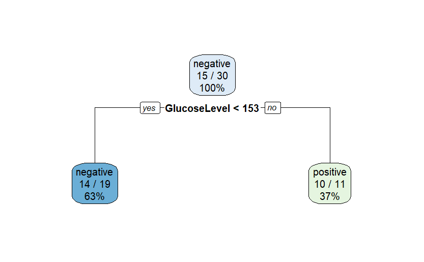

```r
rpart.plot(tree, extra=102)
```

The `rpart` tree gives a split at 153 for Glucose

```r
tree = rpart(Diabetes ~ BMI, data=Table_8_1, method="class")
tree
```

```
n= 30

node), split, n, loss, yval, (yprob)
      * denotes terminal node

1) root 30 15 negative (0.5000000 0.5000000)
  2) BMI< 28.7 9  2 negative (0.7777778 0.2222222) *
  3) BMI>=28.7 21  8 positive (0.3809524 0.6190476) *
```

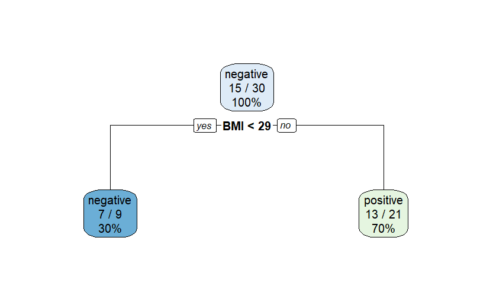

```r
rpart.plot(tree, extra=102)
```

The `rpart` tree gives a split at 29 for BMI. Does it match the book computation?

### Book method; ginit() function

```r
z = Table_8_1 %>% mutate(x=(BMI<25.7))
z
```

| GlucoseLevel | BMI | Diabetes | x |
| --- | --- | --- | --- |
| 110 | 27.8 | negative | FALSE |
| 119 | 29.0 | positive | FALSE |
| 79 | 43.5 | negative | FALSE |
| 122 | 23.0 | negative | TRUE |
| 158 | 29.8 | negative | FALSE |
| 109 | 36.0 | negative | FALSE |
| 158 | 31.6 | positive | FALSE |
| 117 | 30.8 | negative | FALSE |
| 71 | 21.8 | negative | TRUE |
| 97 | 28.2 | negative | FALSE |

[output cut: 20 more lines]

```r
q = table(z$x, z$Diabetes) %>% addmargins
q
```

```
        negative positive Sum
  FALSE       11       15  26
  TRUE         4        0   4
  Sum         15       15  30
```

```r
GiniBMI = (q[2,2]/q[2,3])*(1-(q[2,2]/q[2,3])) + (q[1,2]/q[1,3])*(1-(q[1,2]/q[1,3])) +
          (q[2,1]/q[2,3])*(1-(q[2,1]/q[2,3])) + (q[1,1]/q[1,3])*(1-(q[1,1]/q[1,3]))
GiniBMI
```

```
[1] 0.4881657
```

```r
giniBMI1 = ginit(q)
giniBMI1
```

```
[1] 0.4881657
```

```r
z2 = Table_8_1 %>% mutate(x2=(GlucoseLevel<159))
z2
```

| GlucoseLevel | BMI | Diabetes | x2 |
| --- | --- | --- | --- |
| 110 | 27.8 | negative | TRUE |
| 119 | 29.0 | positive | TRUE |
| 79 | 43.5 | negative | TRUE |
| 122 | 23.0 | negative | TRUE |
| 158 | 29.8 | negative | TRUE |
| 109 | 36.0 | negative | TRUE |
| 158 | 31.6 | positive | TRUE |
| 117 | 30.8 | negative | TRUE |
| 71 | 21.8 | negative | TRUE |
| 97 | 28.2 | negative | TRUE |

[output cut: 20 more lines]

```r
q2 = table(z2$x2, z2$Diabetes) %>% addmargins
q2
```

```
        negative positive Sum
  FALSE        0        8   8
  TRUE        15        7  22
  Sum         15       15  30
```

```r
ginit(q2)
```

```
[1] 0.4338843
```

### Gini search

Functions implemented using `ginit`.

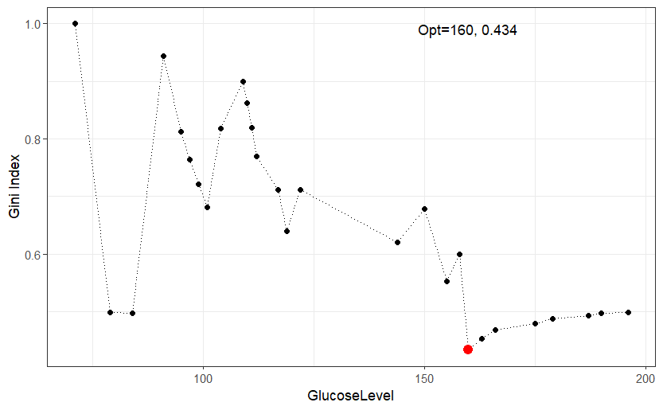

```r
gs = ginisearch(Table_8_1, "GlucoseLevel", "Diabetes")
gs %>% plot_ginisearch + labs(x="GlucoseLevel")
```

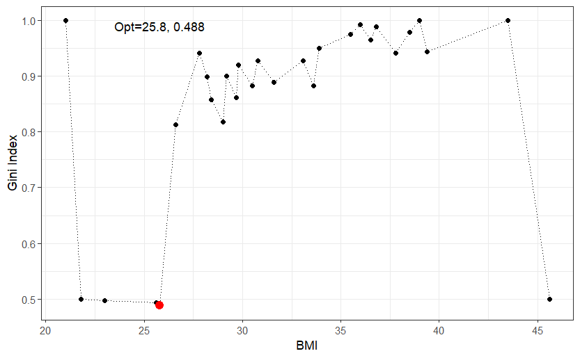

```r
gs = ginisearch(Table_8_1, "BMI", "Diabetes")
gs %>% plot_ginisearch + labs(x="BMI")
```

These give very close to the book answers.

### DescTools Gini Index

Gini index:

```r
library(DescTools)
# t = table(Table_8_1$GlucoseLevel)
z2
```

| GlucoseLevel | BMI | Diabetes | x2 |
| --- | --- | --- | --- |
| 110 | 27.8 | negative | TRUE |
| 119 | 29.0 | positive | TRUE |
| 79 | 43.5 | negative | TRUE |
| 122 | 23.0 | negative | TRUE |
| 158 | 29.8 | negative | TRUE |
| 109 | 36.0 | negative | TRUE |
| 158 | 31.6 | positive | TRUE |
| 117 | 30.8 | negative | TRUE |
| 71 | 21.8 | negative | TRUE |
| 97 | 28.2 | negative | TRUE |

[output cut: 20 more lines]

```r
(z2$x2)*1
```

```
 [1] 1 1 1 1 1 1 1 1 1 1 0 1 0 1 1 1 1 1 1 0 0 1 0 1 1 0 0 1 1 0
```

```r
t = table((z2$x2)*1, z2$Diabetes) %>% addmargins
t %>% str
```

```
 'table' num [1:3, 1:3] 0 15 15 8 7 15 8 22 30
 - attr(*, "dimnames")=List of 2
  ..$ : chr [1:3] "0" "1" "Sum"
  ..$ : chr [1:3] "negative" "positive" "Sum"
```

```r
t
```

```
      negative positive Sum
  0          0        8   8
  1         15        7  22
  Sum       15       15  30
```

```r
tt = t %>% enframe(name="var", value="nn") %>% mutate_all(as.numeric)
```

[output not shown]

# Support Vector Machines (8.2)

We use the `kernlab` package.

```r
library(kernlab)
```

## Data linearly separable

Linearly separable data:

```r
data(Table_8_2)
Table_8_2
```

| GlucoseLevel | BMI | Diabetes |
| --- | --- | --- |
| 110 | 27.8 | negative |
| 79 | 43.5 | negative |
| 109 | 36.0 | negative |
| 175 | 33.6 | positive |
| 179 | 37.8 | positive |
| 155 | 26.6 | positive |
| 95 | 36.8 | negative |
| 144 | 38.5 | positive |
| 112 | 39.4 | negative |
| 160 | 30.5 | positive |

```r
df = Table_8_2 %>% mutate(Diabetes = case_when(Diabetes=="negative" ~ -1,
                                               .default = 1))
df
```

| GlucoseLevel | BMI | Diabetes |
| --- | --- | --- |
| 110 | 27.8 | -1 |
| 79 | 43.5 | -1 |
| 109 | 36.0 | -1 |
| 175 | 33.6 | 1 |
| 179 | 37.8 | 1 |
| 155 | 26.6 | 1 |
| 95 | 36.8 | -1 |
| 144 | 38.5 | 1 |
| 112 | 39.4 | -1 |
| 160 | 30.5 | 1 |

### SVM fit

```r
svmfit = ksvm(Diabetes~GlucoseLevel+BMI, data=df, scaled=FALSE,
              type="C-svc", kernel="vanilladot")
# svmfit %>% glimpse
# outputs from svm
cat("b=", svmfit@b)
```

```
b= 7.925269
```

```r
cat("\ncoef=",paste(svmfit@coef))
```

```
coef= c(0.0019515824685954, -0.0019515824685954)
```

```r
cat("\nalpha=", paste(svmfit@alpha))
```

```
alpha= c(0.0019515824685954, 0.0019515824685954)
```

```r
cat("\nobj=", svmfit@obj)
```

```
obj= -0.001951582
```

```r
cat("\nnSV=", svmfit@nSV)
```

```
nSV= 2
```

```r
cat("\nalphaindex=", paste(svmfit@alphaindex))
```

```
alphaindex= 8:9
```

```r
# Get the indices of support vectors
support_vector_indices <- svmfit@SVindex
cat("\nSVindex=", support_vector_indices)
```

```
SVindex= 8 9
```

```r
# Print support vectors
df3[support_vector_indices, ]
```

[output not shown]

```r
cat("\n")
```

```r
# book w* and calculated objective on p 336.
bstar = -7.93
wstar=c(.0625, -.001763);
cat("\nwstar= ",wstar)
```

```
wstar=  0.0625 -0.001763
```

```r
cat("\nCalculated Objective from wstar= ", (1/2)*( wstar[1]^2 + wstar[2]^2 ) )
```

```
Calculated Objective from wstar=  0.001954679
```

`b` matches the book. `obj` almost matches the calculated objective from the book.

### Figure

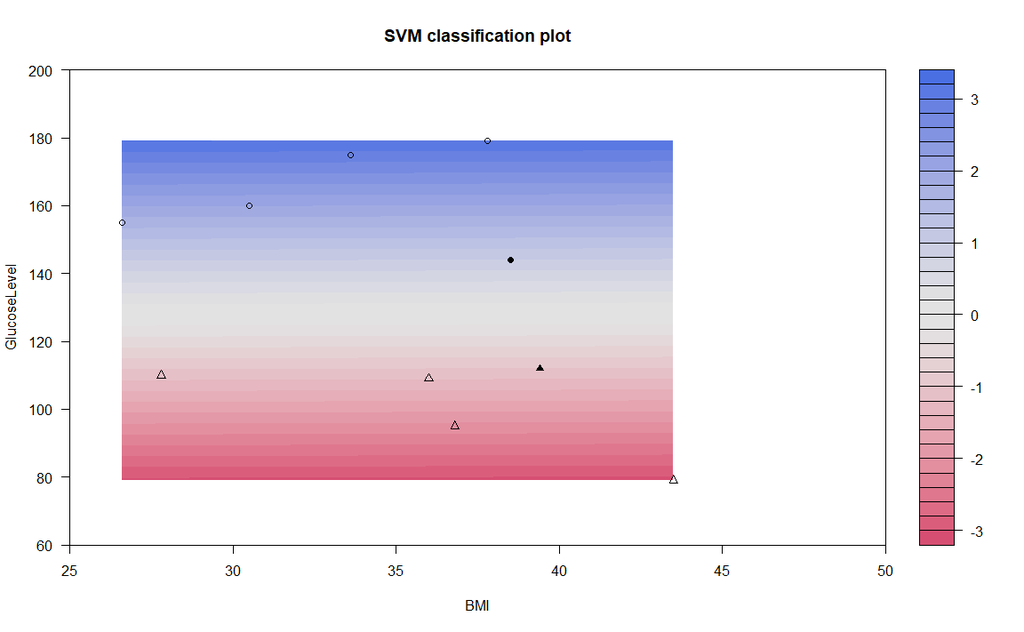

```r
plot(svmfit, data=df, xlim=c(25,50), ylim=c(60,200) )
points(df %>% slice(support_vector_indices))
```

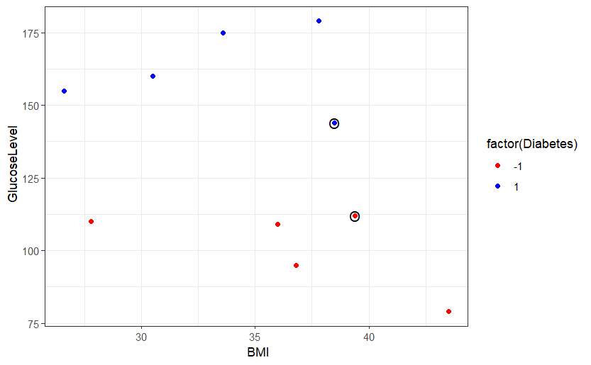

```r
gg_plotsvm_unscaled(svmfit, df, BMI, GlucoseLevel, color=factor(Diabetes))
```

### Figure 8.9

Obviously we do not know how to calculate the support vector.

## Data not linearly separable:

### Figure 8.11

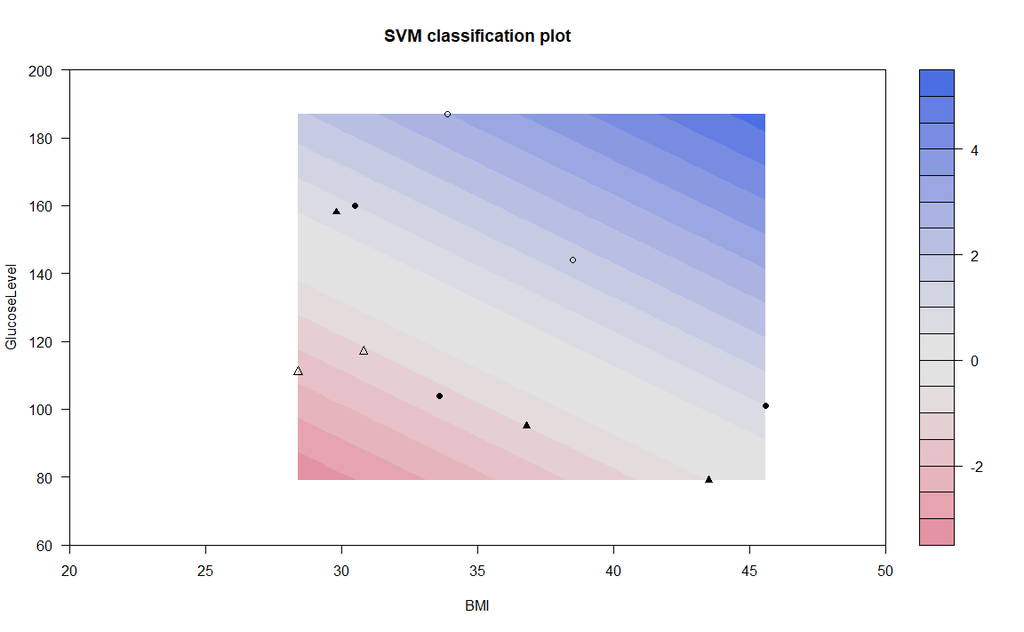

```r
plot(svmfit3, data=df3, xlim=c(20,50), ylim=c(60,200) )
points(df3 %>% slice(support_vector_indices3))
```

[figure not shown]

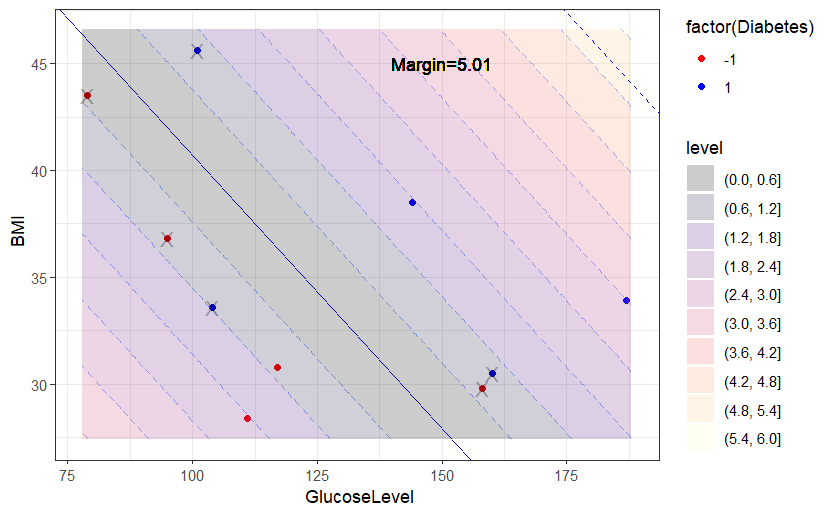

```r
gg_plotsvm(svmfit3, df3,
          GlucoseLevel, BMI, color=factor(Diabetes)) +
  gg_plotsvm_contour(grid=svmgrid(df3, svmfit3), legend=T, bins=10) +
  gg_plotsvm_margin(svmmargin(svmfit3), 150, 45) +
  gg_plotsvm_marginlines(svmfit3)
```

# Confusion Matrix (8.3)

We create a confusion matrix for the hclust example above.

```r
# original df
dfh %>% glimpse
```

[output not shown]

```r
#make table with truth first
cm = table(dfh$Diabetes, dfh$Cluster); cm
```

```
           1 2 3 4
  negative 7 6 2 0
  positive 3 1 6 5
```

```r
# reclassify Cluster 1 and 2 to "neg, and the rest to "pos"
dfh = dfh %>% mutate(NewClus = factor(case_when(Cluster <= 2 ~ "negative",
                                              .default = "positive")))
cm1 = table(dfh$Diabetes, dfh$NewClus)
cm1
```

```
           negative positive
  negative       13        2
  positive        4       11
```

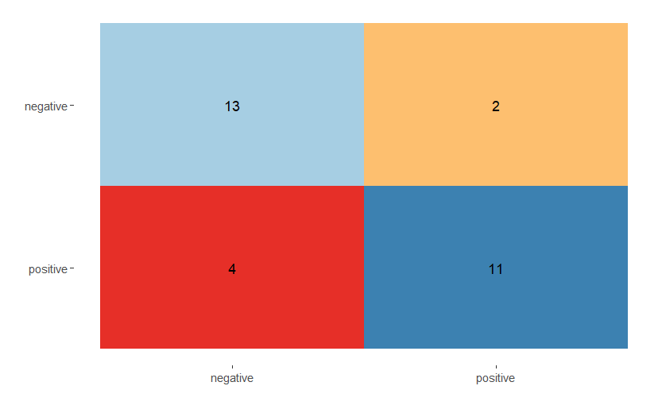

```r
cm1 %>% conf_mat %>% autoplot(type="heatmap") +
  scale_fill_distiller(palette="Paired")
```

```r
# get performance metrics
caret::confusionMatrix(cm1)
```

```
Confusion Matrix and Statistics


           negative positive
  negative       13        2
  positive        4       11

               Accuracy : 0.8
                 95% CI : (0.6143, 0.9229)
    No Information Rate : 0.5667
    P-Value [Acc > NIR] : 0.006664

                  Kappa : 0.6

 Mcnemar's Test P-Value : 0.683091

            Sensitivity : 0.7647
            Specificity : 0.8462
         Pos Pred Value : 0.8667
         Neg Pred Value : 0.7333
             Prevalence : 0.5667
         Detection Rate : 0.4333
   Detection Prevalence : 0.5000
      Balanced Accuracy : 0.8054

       'Positive' Class : negative
```

## ROC and AUC

[figure not shown]

```r
roc_obj %>% glimpse
```

[output not shown]

[figure not shown]

```r
dfroc = tibble(specificities=roc_obj$specificities,
               sensitivities=roc_obj$sensitivities)
ggplot(dfroc) +
  geom_line(aes(specificities, sensitivities), color="blue") +
  geom_abline(aes(intercept=1, slope=-1),
              linetype="dotdash", alpha=.4) +
  annotate("text", x=.5, y=1,
           label=paste0("\nAUC value= ", auc_value))+
  theme_minimal()
```

# References

Mehrotra, Sanjay, Kevin Bui, and Hari Balasubramanian (2024). Healthcare Engineering, Analytics, and Decision Sciences: An Introduction. December 11, 2024. (https://sites.google.com/view/healthcareengineering/)

Machine Learning with Classification (2024) Chapter 11: Trees and Classification. (https://fderyckel.github.io/machinelearningwithr/trees-and-classification.html)